# Regression 2: Implementation in R

Instructor: Yuta Toyama

Last updated: 2020-03-30

# 1 Introduction

## 1.1 Acknowledgement

This note is based on “Introduction to Econometrics with R”. https://www.econometrics-with-r.org/index.html

## 1.2 Preliminary: packages

- We use the following packages:
  - `AER` :
  - `dplyr` : data manipulation
  - `stargazer` : output of regression results

```r
# Install package if you have not done so
# install.packages("AER")
# install.packages("dplyr")
# install.packages("stargazer")
# install.packages("lmtest")

# load packages
library("AER")
library("dplyr")
library("stargazer")
library("lmtest")
```

## 1.3 Empirical setting: Data from California School

- Question: How does the student-teacher ratio affects test scores?
- We use data from California school, which is included in `AER` package.
  - See here for the details: https://www.rdocumentation.org/packages/AER/versions/1.2-6/topics/CASchools

```r
# load the the data set in the workspace
data(CASchools)
```

- Use `class()` function to see `CASchools` is `data.frame` object.

```r
class(CASchools)
```

```
## [1] "data.frame"
```

- We take 2 steps for the analysis.
  - Step 1: Look at data (descriptive analysis)
  - Step 2: Run regression

## 1.4 Step 1: Descriptive analysis

- It is always important to grasp your data before running regression.
- `head()` function give you a first overview of the data.

```r
head(CASchools)
```

|  | district | school | county | grades | students | teachers | calworks | lunch | computer | expenditure | income | english | read | math |
| --- | --- | --- | --- | --- | --- | --- | --- | --- | --- | --- | --- | --- | --- | --- |
| 1 | 75119 | Sunol Glen Unified | Alameda | KK-08 | 195 | 10.90 | 0.5102 | 2.0408 | 67 | 6384.911 | 22.690001 | 0.000000 | 691.6 | 690.0 |
| 2 | 61499 | Manzanita Elementary | Butte | KK-08 | 240 | 11.15 | 15.4167 | 47.9167 | 101 | 5099.381 | 9.824000 | 4.583333 | 660.5 | 661.9 |
| 3 | 61549 | Thermalito Union Elementary | Butte | KK-08 | 1550 | 82.90 | 55.0323 | 76.3226 | 169 | 5501.955 | 8.978000 | 30.000002 | 636.3 | 650.9 |
| 4 | 61457 | Golden Feather Union Elementary | Butte | KK-08 | 243 | 14.00 | 36.4754 | 77.0492 | 85 | 7101.831 | 8.978000 | 0.000000 | 651.9 | 643.5 |
| 5 | 61523 | Palermo Union Elementary | Butte | KK-08 | 1335 | 71.50 | 33.1086 | 78.4270 | 171 | 5235.988 | 9.080333 | 13.857677 | 641.8 | 639.9 |
| 6 | 62042 | Burrel Union Elementary | Fresno | KK-08 | 137 | 6.40 | 12.3188 | 86.9565 | 25 | 5580.147 | 10.415000 | 12.408759 | 605.7 | 605.4 |

- Alternatively, you can use `browse()` to see the entire dataset in browser window.

## 1.5 Create variables

- Create several variables that are needed for the analysis.
- We use `dplyr` for this purpose.

```r
CASchools %>%
  mutate( STR = students / teachers ) %>%
  mutate( score = (read + math) / 2 ) -> CASchools
```

## 1.6 Descriptive statistics

- There are several ways to show descriptive statistics
- The standard one is to use `summary()` function

```r
summary(CASchools)
```

```
##    district            school                  county      grades
##  Length:420         Length:420         Sonoma     : 29   KK-06: 61
##  Class :character   Class :character   Kern       : 27   KK-08:359
##  Mode  :character   Mode  :character   Los Angeles: 27
##                                        Tulare     : 24
##                                        San Diego  : 21
##                                        Santa Clara: 20
##                                        (Other)    :272
##     students          teachers          calworks          lunch
##  Min.   :   81.0   Min.   :   4.85   Min.   : 0.000   Min.   :  0.00
##  1st Qu.:  379.0   1st Qu.:  19.66   1st Qu.: 4.395   1st Qu.: 23.28
##  Median :  950.5   Median :  48.56   Median :10.520   Median : 41.75
##  Mean   : 2628.8   Mean   : 129.07   Mean   :13.246   Mean   : 44.71
##  3rd Qu.: 3008.0   3rd Qu.: 146.35   3rd Qu.:18.981   3rd Qu.: 66.86
##  Max.   :27176.0   Max.   :1429.00   Max.   :78.994   Max.   :100.00
##
##     computer       expenditure       income          english
##  Min.   :   0.0   Min.   :3926   Min.   : 5.335   Min.   : 0.000
##  1st Qu.:  46.0   1st Qu.:4906   1st Qu.:10.639   1st Qu.: 1.941
##  Median : 117.5   Median :5215   Median :13.728   Median : 8.778
##  Mean   : 303.4   Mean   :5312   Mean   :15.317   Mean   :15.768
##  3rd Qu.: 375.2   3rd Qu.:5601   3rd Qu.:17.629   3rd Qu.:22.970
##  Max.   :3324.0   Max.   :7712   Max.   :55.328   Max.   :85.540
##
##       read            math            STR            score
##  Min.   :604.5   Min.   :605.4   Min.   :14.00   Min.   :605.5
##  1st Qu.:640.4   1st Qu.:639.4   1st Qu.:18.58   1st Qu.:640.0
##  Median :655.8   Median :652.5   Median :19.72   Median :654.5
##  Mean   :655.0   Mean   :653.3   Mean   :19.64   Mean   :654.2
##  3rd Qu.:668.7   3rd Qu.:665.9   3rd Qu.:20.87   3rd Qu.:666.7
##  Max.   :704.0   Max.   :709.5   Max.   :25.80   Max.   :706.8
##
```

- This returns the desriptive statistics for all the variables in dataframe.
- You can combine this with `dplyr::select`

```r
CASchools %>%
  select(STR, score) %>%
  summary()
```

```
##       STR            score
##  Min.   :14.00   Min.   :605.5
##  1st Qu.:18.58   1st Qu.:640.0
##  Median :19.72   Median :654.5
##  Mean   :19.64   Mean   :654.2
##  3rd Qu.:20.87   3rd Qu.:666.7
##  Max.   :25.80   Max.   :706.8
```

- You can do a bit lengthly thing manually like this.

```r
# compute sample averages of STR and score
avg_STR <- mean(CASchools$STR)
avg_score <- mean(CASchools$score)

# compute sample standard deviations of STR and score
sd_STR <- sd(CASchools$STR)
sd_score <- sd(CASchools$score)

# set up a vector of percentiles and compute the quantiles
quantiles <- c(0.10, 0.25, 0.4, 0.5, 0.6, 0.75, 0.9)
quant_STR <- quantile(CASchools$STR, quantiles)
quant_score <- quantile(CASchools$score, quantiles)

# gather everything in a data.frame
DistributionSummary <- data.frame(Average = c(avg_STR, avg_score),
                                  StandardDeviation = c(sd_STR, sd_score),
                                  quantile = rbind(quant_STR, quant_score))

# print the summary to the console
DistributionSummary
```

|  | Average | StandardDeviation | quantile.10. | quantile.25. | quantile.40. | quantile.50. | quantile.60. | quantile.75. | quantile.90. |
| --- | --- | --- | --- | --- | --- | --- | --- | --- | --- |
| quant_STR | 19.64043 | 1.891812 | 17.3486 | 18.58236 | 19.26618 | 19.72321 | 20.0783 | 20.87181 | 21.86741 |
| quant_score | 654.15655 | 19.053347 | 630.3950 | 640.05000 | 649.06999 | 654.45000 | 659.4000 | 666.66249 | 678.85999 |

- My personal favorite is to use `stargazer` function.

```r
stargazer(CASchools, type = "text")
```

```
##
## ===========================================================================
## Statistic    N    Mean    St. Dev.     Min    Pctl(25)  Pctl(75)     Max
## ---------------------------------------------------------------------------
## students    420 2,628.793 3,913.105    81        379      3,008    27,176
## teachers    420  129.067   187.913    4.850    19.662    146.350  1,429.000
## calworks    420  13.246    11.455     0.000     4.395    18.981    78.994
## lunch       420  44.705    27.123     0.000    23.282    66.865    100.000
## computer    420  303.383   441.341      0        46       375.2     3,324
## expenditure 420 5,312.408  633.937  3,926.070 4,906.180 5,601.401 7,711.507
## income      420  15.317     7.226     5.335    10.639    17.629    55.328
## english     420  15.768    18.286       0        1.9      23.0       86
## read        420  654.970   20.108    604.500   640.400   668.725   704.000
## math        420  653.343   18.754      605      639.4     665.8      710
## STR         420  19.640     1.892    14.000    18.582    20.872    25.800
## score       420  654.157   19.053    605.550   640.050   666.662   706.750
## ---------------------------------------------------------------------------
```

- You can choose summary statistics you want to report.

```r
CASchools %>%
  stargazer( type = "text", summary.stat = c("n", "p75", "sd") )
```

```
##
## ===================================
## Statistic    N  Pctl(75)  St. Dev.
## -----------------------------------
## students    420   3,008   3,913.105
## teachers    420  146.350   187.913
## calworks    420  18.981    11.455
## lunch       420  66.865    27.123
## computer    420   375.2    441.341
## expenditure 420 5,601.401  633.937
## income      420  17.629     7.226
## english     420   23.0     18.286
## read        420  668.725   20.108
## math        420   665.8    18.754
## STR         420  20.872     1.892
## score       420  666.662   19.053
## -----------------------------------
```

- See https://www.jakeruss.com/cheatsheets/stargazer/#the-default-summary-statistics-table for the details.
- We will use `stargazer` to report regression results.

## 1.7 Scatter plot

- Let’s see how test score and student-teacher-ratio is correlated.

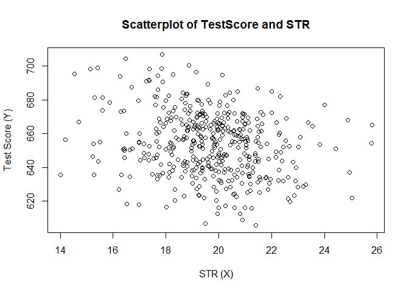

```r
plot(score ~ STR,
     data = CASchools,
     main = "Scatterplot of TestScore and STR",
     xlab = "STR (X)",
     ylab = "Test Score (Y)")
```

- Use `cor()` to compute the correlation between two numeric vectors.

```r
cor(CASchools$STR, CASchools$score)
```

```
## [1] -0.2263627
```

## 1.8 Step 2: Run regression

## 1.9 Simple linear regression

- We use `lm()` function to run linear regression
- First, consider the simple linear regression
  $$score_i = \beta_0 + \beta_1 size_i + \epsilon_i$$
  where $size_i$ is the class size (student-teacher-ratio).
  - From now on we call student-teacher-ratio (STR) class size.
- To run this regression, we use `lm`

```r
# First, we rename the variable `STR`
CASchools %>%
  dplyr::rename( size = STR) -> CASchools

# Run regression and save results in the varaiable `model1_summary`
model1_summary <- lm( score ~ size, data = CASchools)

# See the results
summary(model1_summary)
```

```
##
## Call:
## lm(formula = score ~ size, data = CASchools)
##
## Residuals:
##     Min      1Q  Median      3Q     Max
## -47.727 -14.251   0.483  12.822  48.540
##
## Coefficients:
##             Estimate Std. Error t value             Pr(>|t|)
## (Intercept) 698.9329     9.4675  73.825 < 0.0000000000000002 ***
## size         -2.2798     0.4798  -4.751           0.00000278 ***
## ---
## Signif. codes:  0 '***' 0.001 '**' 0.01 '*' 0.05 '.' 0.1 ' ' 1
##
## Residual standard error: 18.58 on 418 degrees of freedom
## Multiple R-squared:  0.05124,    Adjusted R-squared:  0.04897
## F-statistic: 22.58 on 1 and 418 DF,  p-value: 0.000002783
```

- Interpretations
  - An increase of one student per teacher leads to 2.2 point decrease in test scores.
  - p value is very small. The effect of the class size on test score is significant. Note: Be careful. These standard errors are NOT heteroskedasiticity robust. We will come back to this point soon.
  - $R^2 = 0.051$, implying that 5.1% of the variance of the dependent variable is explained by the model.
- You can add more variable in the regression (will see this soon)

## 1.10 Correction of Robust standard error

- We use `vcovHC()` function, a partof the package `sandwich`, to obtain the robust standard errors.
  - The package `sandwich` is automatically loaded if you load `AER` package.

```r
# compute heteroskedasticity-robust standard errors
vcov <- vcovHC(model1_summary, type = "HC1")

# get standard error: the square root of the diagonal element in vcov
robust_se <- sqrt(diag(vcov))
robust_se
```

```
## (Intercept)        size
##  10.3643617   0.5194893
```

- Notice that robust standard errors are larger than the one we obtained from `lm`!
- How to combine the robust standard errors with the original summary? Use `coeftest()` from the package `lmtest`

```r
# load `lmtest`
library(lmtest)

# Combine robust standard errors
coeftest(model1_summary, vcov. = vcov)
```

```
##
## t test of coefficients:
##
##              Estimate Std. Error t value              Pr(>|t|)
## (Intercept) 698.93295   10.36436 67.4362 < 0.00000000000000022 ***
## size         -2.27981    0.51949 -4.3886            0.00001447 ***
## ---
## Signif. codes:  0 '***' 0.001 '**' 0.01 '*' 0.05 '.' 0.1 ' ' 1
```

## 1.11 Report by Stargazer

- `stargazer` is useful to show the regression result.

```r
# load
library(stargazer)

# Create output by stargazer
stargazer::stargazer(model1_summary, type ="text")
```

```
##
## ===============================================
##                         Dependent variable:
##                     ---------------------------
##                                score
## -----------------------------------------------
## size                         -2.280***
##                               (0.480)
##
## Constant                    698.933***
##                               (9.467)
##
## -----------------------------------------------
## Observations                    420
## R2                             0.051
## Adjusted R2                    0.049
## Residual Std. Error      18.581 (df = 418)
## F Statistic           22.575*** (df = 1; 418)
## ===============================================
## Note:               *p<0.1; **p<0.05; ***p<0.01
```

- Use robust standard errors in stargazer output

```r
# Prepare robust standard errors in list
rob_se <- list( sqrt(diag(vcovHC(model1_summary, type = "HC1") ) ) )

# generate regression table.

stargazer( model1_summary,
           se = rob_se,
           type = "text")
```

```
##
## ===============================================
##                         Dependent variable:
##                     ---------------------------
##                                score
## -----------------------------------------------
## size                         -2.280***
##                               (0.519)
##
## Constant                    698.933***
##                              (10.364)
##
## -----------------------------------------------
## Observations                    420
## R2                             0.051
## Adjusted R2                    0.049
## Residual Std. Error      18.581 (df = 418)
## F Statistic           22.575*** (df = 1; 418)
## ===============================================
## Note:               *p<0.1; **p<0.05; ***p<0.01
```

## 1.12 Full results

Taken from https://www.econometrics-with-r.org/7-6-analysis-of-the-test-score-data-set.html

```r
# load the stargazer library

# estimate different model specifications
spec1 <- lm(score ~ size, data = CASchools)
spec2 <- lm(score ~ size + english, data = CASchools)
spec3 <- lm(score ~ size + english + lunch, data = CASchools)
spec4 <- lm(score ~ size + english + calworks, data = CASchools)
spec5 <- lm(score ~ size + english + lunch + calworks, data = CASchools)

# gather robust standard errors in a listh
rob_se <- list(sqrt(diag(vcovHC(spec1, type = "HC1"))),
               sqrt(diag(vcovHC(spec2, type = "HC1"))),
               sqrt(diag(vcovHC(spec3, type = "HC1"))),
               sqrt(diag(vcovHC(spec4, type = "HC1"))),
               sqrt(diag(vcovHC(spec5, type = "HC1"))))

# generate a LaTeX table using stargazer
stargazer(spec1, spec2, spec3, spec4, spec5,
          se = rob_se,
          digits = 3,
          header = F,
          column.labels = c("(I)", "(II)", "(III)", "(IV)", "(V)"),
          type ="text",
          keep.stat = c("N", "adj.rsq"))
```

```
##
## ===================================================================
##                               Dependent variable:
##              ------------------------------------------------------
##                                      score
##                 (I)        (II)      (III)       (IV)       (V)
##                 (1)        (2)        (3)        (4)        (5)
## -------------------------------------------------------------------
## size         -2.280***   -1.101**  -0.998***  -1.308***  -1.014***
##               (0.519)    (0.433)    (0.270)    (0.339)    (0.269)
##
## english                 -0.650***  -0.122***  -0.488***  -0.130***
##                          (0.031)    (0.033)    (0.030)    (0.036)
##
## lunch                              -0.547***             -0.529***
##                                     (0.024)               (0.038)
##
## calworks                                      -0.790***    -0.048
##                                                (0.068)    (0.059)
##
## Constant     698.933*** 686.032*** 700.150*** 697.999*** 700.392***
##               (10.364)   (8.728)    (5.568)    (6.920)    (5.537)
##
## -------------------------------------------------------------------
## Observations    420        420        420        420        420
## Adjusted R2    0.049      0.424      0.773      0.626      0.773
## ===================================================================
## Note:                                   *p<0.1; **p<0.05; ***p<0.01
```

- The coefficient on the class size decreases as we add more explantory variables. Can you explain why? (Hint: omitted variable bias)